# Schools and Colleges

Najah

07/04/2021

### 0.0.1 Document History

Original Publish Date: 7th March, 2021

Updated on: 28 April, 2021

# 1 UP

The [All India Survey on Higher Education (AISHE)](http://aishe.nic.in/) website provided two kind of college data. 1, Colleges affiliated to Universities. 2, Stand alone institutions.

## 1.1 Data summary

|  | District | University.Type | University.Name | inst_type | college_name | college_type | Address | Website | Management | year_estd | Specialised.in | Location | Upload.Year | full_name | full_adress | lat | long | AC_NO | AC_NAME | PC_NO | PC_NAME | Longitude | Latitude | ST_Name |
| --- | --- | --- | --- | --- | --- | --- | --- | --- | --- | --- | --- | --- | --- | --- | --- | --- | --- | --- | --- | --- | --- | --- | --- | --- |
| 1 | Agra | State Public University | Dr.A.P.J. ABDUL KALAM TECHNICAL UNIVERSITY ,LUCKNOW (Id: U-0549) | Affiliated | ACE COLLEGE OF ENGINEERING AND MANAGEMENT,ETMADPURA,AGRA. (Id: C-46035) | Affiliated College | 17 Km Stone, Agra-Kanpur Road ,, NH-2, Etmadpur, Agra, AGRA | www.acecollegeagra.com | Private Un-Aided | 2012 | Engineering &amp; Technology | Rural | 2019 | ACE COLLEGE OF ENGINEERING AND MANAGEMENT | ACE COLLEGE OF ENGINEERING AND MANAGEMENT,17 Km Stone, Agra-Kanpur Road ,, NH-2, Etmadpur, Agra, AGRA,Agra,Uttar Pradesh,India | 27.20939 | 78.06546 | 86 | Etmadpur | 18 | AGRA (SC) |  |  |  |
| 2 | Agra | State Public University | Dr.A.P.J. ABDUL KALAM TECHNICAL UNIVERSITY ,LUCKNOW (Id: U-0549) | Affiliated | CBS COLLEGE OF MANAGEMENT,AGRA. (Id: C-46036) | Affiliated College | CBS COLLEGE OF MANAGEMENT,AGRA., POIYA HATHRAS ROAD, AGRA | www.cbsmanagement.org | Private Un-Aided | 2012 | Management | Rural | 2019 | CBS COLLEGE OF MANAGEMENT | CBS COLLEGE OF MANAGEMENT,CBS COLLEGE OF MANAGEMENT,AGRA., POIYA HATHRAS ROAD, AGRA,Agra,Uttar Pradesh,India | 27.22063 | 77.93009 | 89 | Agra North | 18 | AGRA (SC) |  |  |  |
| 3 | Agra | State Public University | Dr.A.P.J. ABDUL KALAM TECHNICAL UNIVERSITY ,LUCKNOW (Id: U-0549) | Affiliated | CHAUDHARY BEERI SINGH COLLEGE OF ENGINEERING AND MANAGEMENT, ETMADPUR, AGRA (Id: C-46028) | Affiliated College | CH.BEERI SINGH COLLEGE OF ENGINEERING &amp; MANAGEMENT,, POIYA NEAR 400 KV SAB STATION, PILI POKHAR, ALIGARH ROAD,, AGRA | www.cbsengg.org | Private Un-Aided | 2009 | Engineering &amp; Technology | Rural | 2019 | CHAUDHARY BEERI SINGH COLLEGE OF ENGINEERING AND MANAGEMENT | CHAUDHARY BEERI SINGH COLLEGE OF ENGINEERING AND MANAGEMENT,CH.BEERI SINGH COLLEGE OF ENGINEERING &amp; MANAGEMENT,, POIYA NEAR 400 KV SAB STATION, PILI POKHAR, ALIGARH ROAD,, AGRA,Agra,Uttar Pradesh,… | 27.20245 | 77.94525 | 89 | Agra North | 18 | AGRA (SC) |  |  |  |
| 4 | Agra | State Public University | Dr.A.P.J. ABDUL KALAM TECHNICAL UNIVERSITY ,LUCKNOW (Id: U-0549) | Affiliated | HERITAGE INSTITUTE OF HOTEL AND TOURISM, AGRA (Id: C-46030) | Affiliated College | 13 KM MILES STONE, HERITAGE KNOWLEDGE CITY, BAMRAULI KATARA FATEHABAD ROAD | http://www.hihtworld.com | Private Un-Aided | 2010 | No | Rural | 2019 | HERITAGE INSTITUTE OF HOTEL AND TOURISM | HERITAGE INSTITUTE OF HOTEL AND TOURISM,13 KM MILES STONE, HERITAGE KNOWLEDGE CITY, BAMRAULI KATARA FATEHABAD ROAD,Agra,Uttar Pradesh,India | 27.15806 | 78.03509 | 87 | Agra Cantt. (SC) | 18 | AGRA (SC) |  |  |  |
| 5 | Agra | State Public University | Dr.A.P.J. ABDUL KALAM TECHNICAL UNIVERSITY ,LUCKNOW (Id: U-0549) | Affiliated | KRISHNA PHARMACY COLLEGE (Id: C-63810) | Affiliated College | VILL. LARAMDA POST BICHPURI, AGRA | www.krishnapharmacy.co.in | Private Un-Aided | 2019 | No | Rural | 2019 | KRISHNA PHARMACY COLLEGE | KRISHNA PHARMACY COLLEGE ,VILL. LARAMDA POST BICHPURI, AGRA,Agra,Uttar Pradesh,India | 27.17343 | 77.89541 | 90 | Agra Rural (SC) | 19 | FATEHPUR SIKRI |  |  |  |
| 6 | Agra | State Public University | Dr.A.P.J. ABDUL KALAM TECHNICAL UNIVERSITY ,LUCKNOW (Id: U-0549) | Affiliated | Sri Ram Gopal College of Pharmacy (Id: C-62074) | Affiliated College | MANDI MIRZA KHAN ROAD, PATSAL FATH PUR SIKRI, AGRA | www.grgm.co.in | Private Un-Aided | 2019 | Pharmacy | Rural | 2019 | Sri Ram Gopal College of Pharmacy | Sri Ram Gopal College of Pharmacy ,MANDI MIRZA KHAN ROAD, PATSAL FATH PUR SIKRI, AGRA,Agra,Uttar Pradesh,India | 27.17596 | 77.98527 | 88 | Agra South | 18 | AGRA (SC) |  |  |  |

### 1.1.1 Main variables

```
##  [1] "District"        "University.Type" "University.Name" "inst_type"
##  [5] "college_name"    "college_type"    "Address"         "Website"
##  [9] "Management"      "year_estd"       "Specialised.in"  "Location"
## [13] "Upload.Year"     "full_name"       "full_adress"     "lat"
## [17] "long"            "AC_NO"           "AC_NAME"         "PC_NO"
## [21] "PC_NAME"         "Longitude"       "Latitude"        "ST_Name"
```

### 1.1.2 types of management

```
## # A tibble: 5 x 2
##   Management         count
##   <chr>              <int>
## 1 Central Government    11
## 2 Local Body           344
## 3 Private Aided        314
## 4 Private Un-Aided    5801
## 5 State Government     429
```

### 1.1.3 Year by year break-up of number of colleges

I kept *Private un-aided* as private and clubbed all others as government colleges.

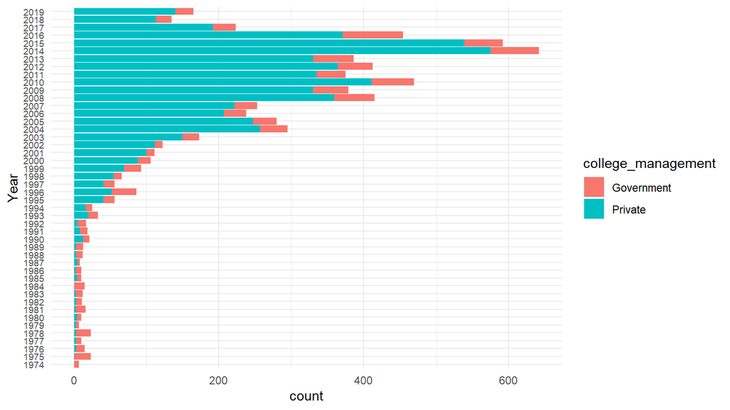

After my initial inspections, I went to merge the college data with UP dynasties data after allotting the coleges to each election year based on the year of establishment

```
## # A tibble: 12 x 2
##    year_el count
##    <chr>   <int>
##  1 1974       55
##  2 1980       64
##  3 1985       43
##  4 1987       40
##  5 1989       40
##  6 1991       50
##  7 1993      167
##  8 1996      554
##  9 2002     1239
## 10 2007     2050
## 11 2012     2297
## 12 2017      300
```

Average number of colleges built every year in a constituency is 1.37

### 1.1.4 Distribution of number of colleges in a constituency

This density chart shows the distribution of the number of colleges built in different constituencies during last 10 years

#### 1.1.4.1 Post 2009

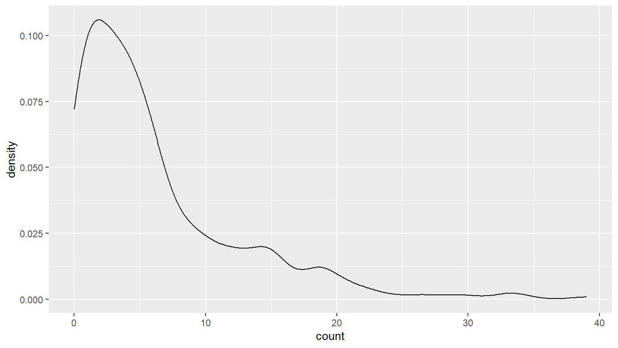

#### 1.1.4.2 Pre 2009

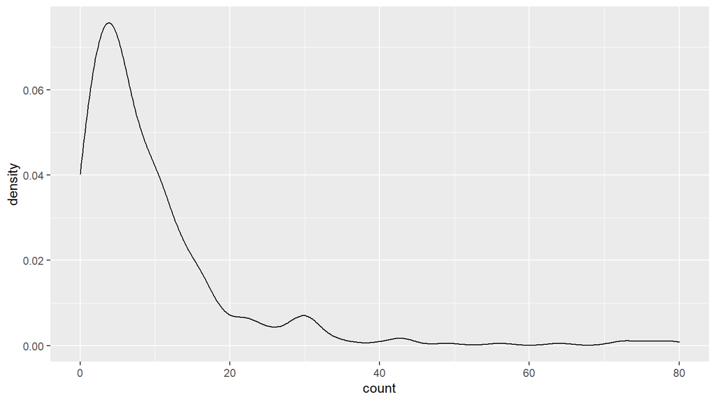

## 1.2 regressions

### 1.2.1 Dynast definition 2

regression run on dynast definition 2

#### 1.2.1.1 All years

In this regression we look at colleges built during the rule of MLAs selected during the election cycles starting from 1974 to 2017

|  | fit.poisson | fit.probit |
| --- | --- | --- |
| Dependent Var.: | n_colleges | n_college_bin |
| dyn_cum_2 | -0.0140 (0.1075) | -0.2462* (0.1171) |
| term_duration | -0.0682 (0.1139) | -0.1124 (0.1596) |
| turnout_percentage | -0.0081 (0.0082) | -0.0072 (0.0071) |
| margin_percentage | 0.0020 (0.0051) | -0.0057 (0.0037) |
| constituency_typeSC | -0.0863 (0.1964) | 0.1361 (0.2613) |
| enop | 0.0030 (0.0549) | -0.0984* (0.0446) |
| log(electors) | 0.1101 (0.3834) | 0.1188 (0.4021) |
| Caste control | Yes | Yes |
| Fixed-Effects: | —————- | —————– |
| year_el | Yes | Yes |
| constituency_name | Yes | Yes |
| ___________________ | ________________ | _________________ |
| Family | quasipoisson(“log”) | Probit |
| S.E.: Clustered | by: constituen.. | by: constituenc.. |
| Observations | 4,275 | 4,177 |
| Squared Cor. | 0.65490 | 0.53951 |
| Pseudo R2 | – | 0.47348 |
| BIC | – | 7,228.6 |

#### 1.2.1.2 Post 1991

- Tried post 1991 and 1996. Dynast co-effient on both are negative. The model below is post 1991.

|  | fit.poisson | fit.probit |
| --- | --- | --- |
| Dependent Var.: | n_colleges | n_college_bin |
| dyn_cum_2 | -0.0765 (0.0961) | -0.1872* (0.0824) |
| term_duration | 0.0173 (0.0491) | 0.0028 (0.0597) |
| turnout_percentage | -0.0209*** (0.0054) | -0.0050 (0.0046) |
| margin_percentage | 0.0044 (0.0038) | 0.0036 (0.0034) |
| enop | -0.0310 (0.0435) | -0.0524 (0.0434) |
| log(electors) | 0.9001* (0.3659) | 0.7062. (0.3942) |
| constituency_typeSC | -0.1897 (0.1556) | 0.0129 (0.1232) |
| Caste control | Yes | Yes |
| Fixed-Effects: | ——————- | —————– |
| year_el | Yes | Yes |
| district_name | Yes | Yes |
| ___________________ | ___________________ | _________________ |
| Family | quasipoisson(“log”) | Probit |
| S.E.: Clustered | by: district_name | by: district_name |
| Observations | 2,811 | 2,811 |
| Squared Cor. | 0.36457 | 0.37467 |
| Pseudo R2 | – | 0.31312 |
| BIC | – | 3,407.7 |

#### 1.2.1.3 1993-2012 with night lights

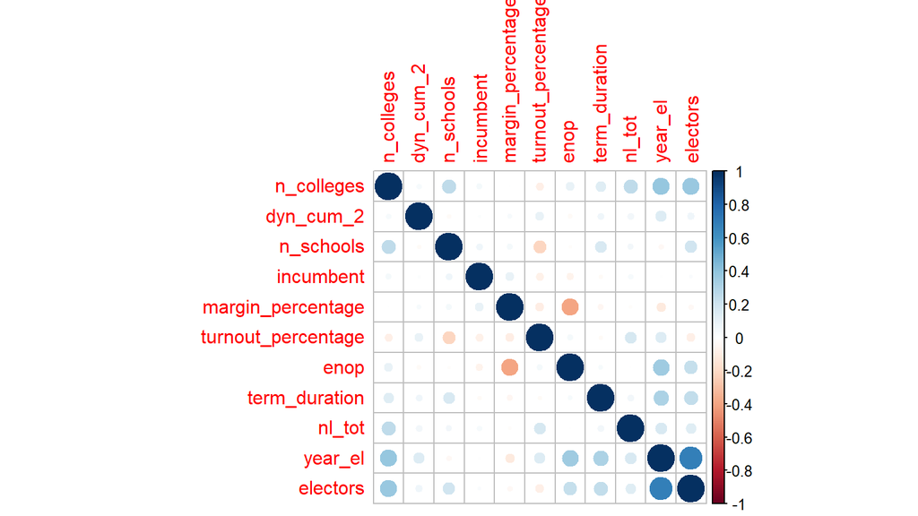

UP colleges - Poisson model

|  | fit.poisson | fit.probit |
| --- | --- | --- |
| Dependent Var.: | n_colleges | n_college_bin |
| dyn_cum_2 | -0.0328 (0.1000) | -0.2310* (0.1118) |
| incumbent | 0.0145 (0.0836) | 0.0634 (0.1066) |
| margin_percentage | 0.0023 (0.0044) | 0.0043 (0.0055) |
| turnout_percentage | -0.0205** (0.0066) | -0.0052 (0.0071) |
| enop | 0.0014 (0.0433) | -0.0530 (0.0560) |
| term_duration | 0.0508 (0.0866) | -0.0226 (0.1249) |
| n_schools | 0.0017*** (0.0002) | 0.0007** (0.0002) |
| nl_tot | 4.86e-5*** (1.2e-5) | 3.54e-5* (1.59e-5) |
| constituency_typeSC | -0.2388** (0.0825) | 0.0828 (0.1660) |
| log(electors) | 0.1048 (0.4017) | 0.5982 (0.5389) |
| no_terms | 0.0073 (0.0434) | -0.0119 (0.0413) |
| caste_uc |  | 0.1364 (0.1658) |
| caste_yadav |  | 0.2643 (0.2497) |
| caste_non_yadav_obc |  | 0.2391 (0.1927) |
| caste_dalit |  | 0.1776 (0.1811) |
| caste_muslim |  | 0.3901. (0.2189) |
| Fixed-Effects: | ——————- | —————— |
| year_el | Yes | Yes |
| district_name | Yes | Yes |
| ___________________ | ___________________ | __________________ |
| Family | quasipoisson(“log”) | Probit |
| S.E.: Clustered | by: district_name | by: district_name |
| Observations | 2,097 | 2,097 |
| Squared Cor. | 0.40332 | 0.31772 |
| Pseudo R2 | – | 0.28635 |
| BIC | – | 2,548.7 |

#### 1.2.1.4 adr variables

Inorder to use the adr variables in the model, I have to limit the years to post 2009.

[output not shown]

# 2 India

There were **45022** affiliated colleges **11987** stand-alone colleges. Among these two categories, only **52232** observations had year of establishment. This further reduced to **49959** observations after geocoding .

## 2.1 Data summary

### 2.1.1 Year by year break-up of number of colleges

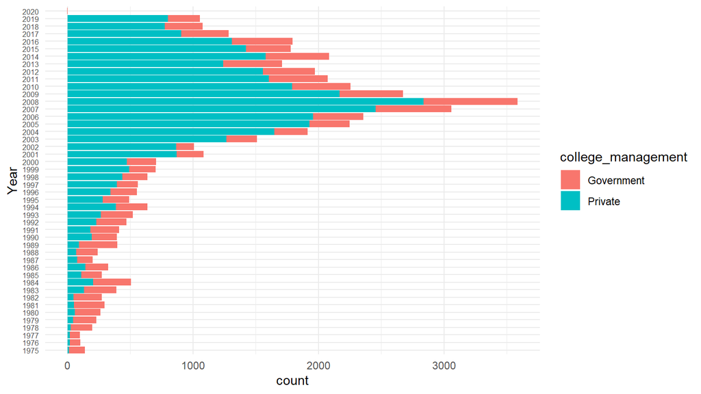

### 2.1.2 state break-up

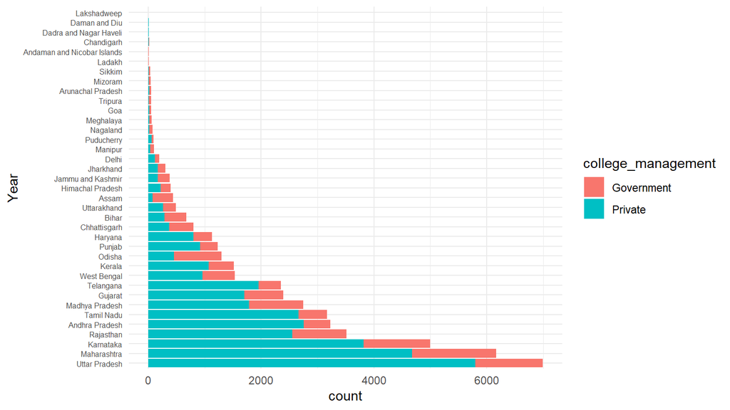

We are focusing on data post 2009 since we only have pan-India dynasty data after 2009. Thus in our college data set before mergin with dynasty has **19148** observations.

### 2.1.3 State wise break-up post 2009

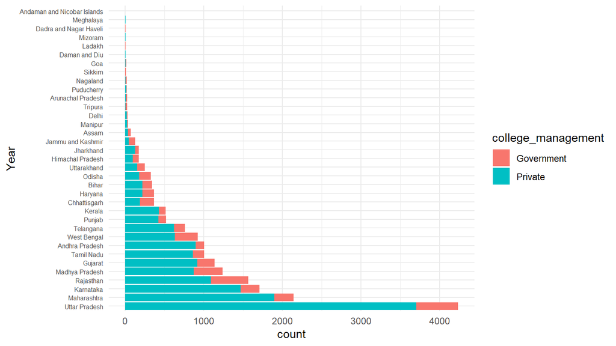

Average number of colleges built in a constituency in India during last 10 years is 1.67

### 2.1.4 Distribution of number of colleges established every election year in a constituency

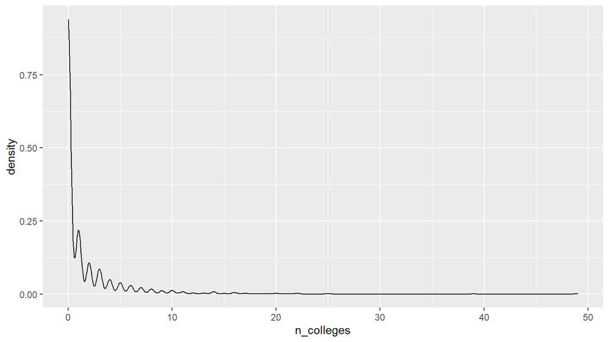

### 2.1.5 Distributions of the number colleges established in the constituencies during 2009&2014

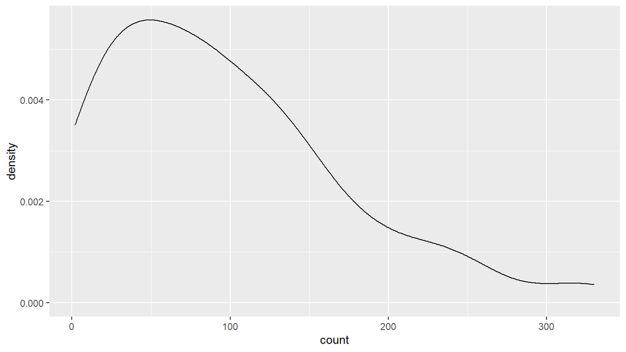

## 2.2 regressions

All pan-india regressions are run on colleges built during 2009-19 at PC level.

### 2.2.1 All colleges

**Regression Results - India all colleges**

|  | *Dependent variable:* |  |  |  |
| --- | --- | --- | --- | --- |
|  | n_colleges |  |  | n_college_binary |
|  | *OLS* | *normal* | *glm: quasipoisson* | *probit* |
|  |  |  | *link = log* |  |
|  | (1) | (2) | (3) | (4) |
| dyn | -0.277** | -0.277** | -0.154*** | -0.070 |
|  | (0.117) | (0.117) | (0.045) | (0.072) |
| Year fixed effects | Yes | Yes | Yes | Yes |
| State fixed effects | Yes | Yes | Yes | Yes |
| Observations | 4,631 | 4,631 | 4,631 | 4,631 |
| R<sup>2</sup> | 0.288 |  |  |  |
| Adjusted R<sup>2</sup> | 0.282 |  |  |  |
| Akaike Inf. Crit. |  | 23,555.670 |  | 3,188.970 |
| *Note:* | p<0.1; p<0.05; p<0.01 |  |  |  |

**Regression Results - India private colleges**

[output not shown]

### 2.2.2 Model with controls - 2009 :2019

India colleges - Poisson model

|  | fe2 |
| --- | --- |
| Dependent Var.: | n_colleges |
| dyn | -0.1164 (0.0813) |
| incumbentTRUE | -0.1962. (0.1135) |
| margin_percentage | -0.0121** (0.0040) |
| turnout_percentage | 0.0005 (0.0081) |
| enop | 0.1071 (0.0742) |
| constituency_typeSC | -0.2997. (0.1617) |
| constituency_typeST | 0.3477. (0.1804) |
| log(electors) | 0.2561 (0.7724) |
| no_terms | -0.0412* (0.0180) |
| log(total_assets) | 0.0123 (0.0197) |
| serious_crime | -0.0075 (0.0399) |
| non_serious_crime | 0.0126 (0.0237) |
| edu | -0.0136. (0.0076) |
| Fixed-Effects: | —————— |
| year_el | Yes |
| State | Yes |
| ___________________ | __________________ |
| S.E.: Clustered | by: State |
| Observations | 2,763 |
| Squared Cor. | 0.35990 |
| Pseudo R2 | 0.34152 |
| BIC | 11,599.0 |